# UW Madison Analysis Term Project

Morgan Throckmorton

May 2, 2019

For this project, I will be analyzing the data on grades given from 2006 to 2017 at the University of Wisconsin, Madison that can be found on Kaggle at https://www.kaggle.com/Madgrades/uw-madison-courses. I will use this data to investigate and answer the following questions.

1. For each of the roughly 193,000 course sections in this dataset, calculate the average of the grades for each course. Explain how you handled non-letter grades such as ‘nr’ and ‘cr’.
2. Are there any courses, sections, or subjects that stand out as having the lowest average GPA or the highest average GPA?
3. Do the grades given by the individual instructors seem to stay the same over time or do they have any type of trend over time? If there is a trend, is it consistent across instructors or do any vary among intructors?
4. Which 5 subject areas had the most professors in 2017? Pick a subject area with many professors. Scrape data on the professor’s ratings from rate my professor and determine if these ratings have any correlation with the overall average GPA assigned by the professor over a reasonable time period.

Along with providing answers, I will be explaining how I approached the dataset and justify why I chose to use a particular method.

## Exploring the Data

Before starting anything, I wanted to first familiarize myself with the data. Without a big picture understanding of how all of the tables in the database related to each other, it would have been much more difficult to understand what I wanted to ultimately use. One of the first things I did was create the following relational database map.

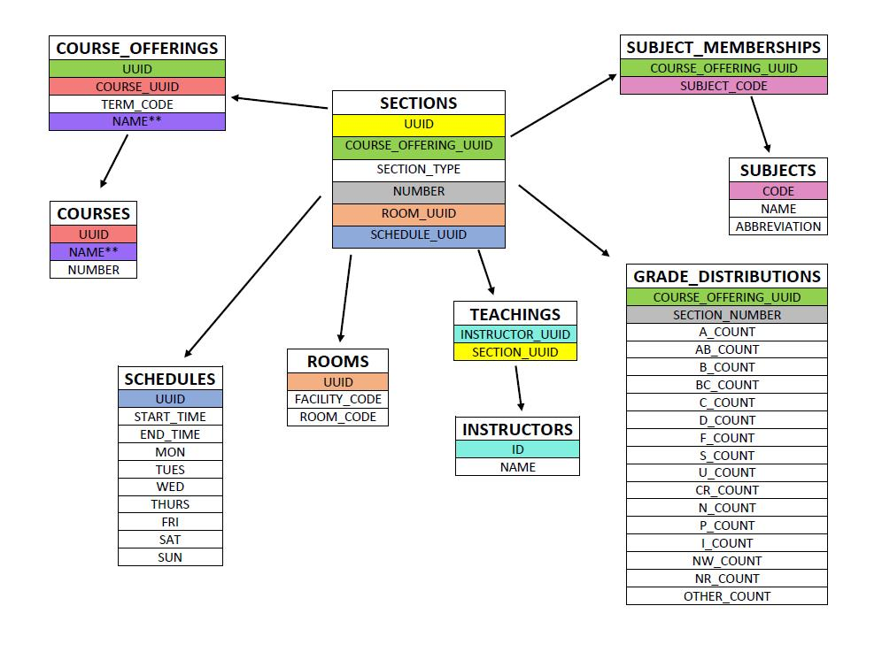

I used this relational database map to help me understand the information I wanted to use and how I would strategically merge the data. After looking through the questions and considering what information would be most useful, I decided to omit the **rooms** table and the **schedules** table from my analysis. It seemed unlikely that the location of any particular class would have any widespread effect on the analysis of student’s grades, so omitting the **rooms** table was a pretty easy decision. For the **schedules** table, my first thought was to use the *start_time* and the *end_time* to factor each of the classes into a “morning”, “afternoon”, or “evening” class, but after further consideration, I opted to make the focus on other factors that were likely to make a larger impact.

## Cleaning the Data

#### Term Codes

One of the first pieces of information I wanted to collect was not available in the dataset but could be found at http://www.bussvc.wisc.edu/bursar/termcode.html. This site contained the SIS term codes from the Bursar’s Office that attach a year and a term–spring, summer, or fall–to the column *term_code* in the **course_offerings** table. I wanted to use this information for the analysis of grades so in order to collect it I just copied and pasted it into Excel and then imported it into R as the data frame **term_codes**.

```r
head(term_codes)
```

```
##   Calendar.Year Spring.Term Summer.Term Fall.Term
## 1          2001        1014        1016      1022
## 2          2002        1024        1026      1032
## 3          2003        1034        1036      1042
## 4          2004        1044        1046      1052
## 5          2005        1054        1056      1062
## 6          2006        1064        1066      1072
```

Then I cleaned this and converted it to a form that would make it easy to merge with other data later.

```r
fall <- term_codes[,c(1,4)]
spring <- term_codes[,c(1,2)]
fall$semester <- 'Fall'
spring$semester <- 'Spring'
colnames(fall) <- c('year','term_code','semester')
colnames(spring) <- c('year','term_code','semester')
term <- rbind(fall,spring)
head(term, n = 2)
```

```
##   year term_code semester
## 1 2001      1022     Fall
## 2 2002      1032     Fall
```

```r
tail(term, n = 2)
```

```
##     year term_code semester
## 531 2049      1494   Spring
## 541 2050      1504   Spring
```

#### Course Offerings and Courses

The next data I imported were the ***course_offerings** and **courses** tables.

```r
head(course_offerings, n = 3)
```

```
##                                   uuid
## 1 344b3ebe-da7e-314c-83ed-9425269695fd
## 2 f718e6cd-33f0-3c14-a9a6-834d9c3610a8
## 3 ea3b717c-d66b-30dc-8b37-964d9688295f
##                            course_uuid term_code
## 1 a3e3e1c3-543d-3bb5-ae65-5f2aec4ad1de      1092
## 2 a3e3e1c3-543d-3bb5-ae65-5f2aec4ad1de      1082
## 3 a3e3e1c3-543d-3bb5-ae65-5f2aec4ad1de      1172
```

```r
head(courses, n = 3)
```

```
##                                   uuid
## 1 a3e3e1c3-543d-3bb5-ae65-5f2aec4ad1de
## 2 c070a84f-648f-351d-9499-5d0e30ad02cc
## 3 e6b4b7ae-0e0b-3aa5-9d77-7fcd90c9cfa3
##                                                         name
## 1                              Cooperative Education Program
## 2 Cooperative Education/Co-op in Life Sciences Communication
## 3                              Cooperative Education Program
```

Note that I decided to omit *names* from the **course_offerings** table. This is because there were missing values and I would rather have merged the two tables together and use the names from the **courses** table. I also ommitted the *numbers* from the **courses** table since the data dictionary said these values were not unique.

I first changed the column names so that the data would properly merge.

```r
colnames(courses) <- c('course_uuid','course_name')
colnames(course_offerings)[1] <- 'course_offering_uuid'
```

Then I merged the data together while omitting *course_uuid* since this was only needed to merge these two tables together.

```r
courses <- merge(course_offerings,courses)[,-1]
head(courses, n = 3)
```

```
##                   course_offering_uuid term_code               course_name
## 1 f3e8a8bd-72c0-3899-b0bf-dfbefe0224e0      1102 Fifth Semester Vietnamese
## 2 654c3900-d924-3ed7-ae56-8201312b33f9      1162 Fifth Semester Vietnamese
## 3 37fe0908-bdce-3433-b017-a8862c313567      1082 Fifth Semester Vietnamese
```

Now that I had the **courses** and **course_offerings** together, I merged it with **term_codes**. Since all I wanted from the *term_codes* was the *year* and *semester*, I chose to go ahead and remove *term_codes* from the data set as well.

```r
course_info <- merge(courses,term)[,-1]
head(course_info, n = 3)
```

```
##                   course_offering_uuid
## 1 3982dd85-6a41-3658-a0f9-8d11b50cc848
## 2 b96bf3e9-ba7c-3aa7-8957-ed0195bae121
## 3 829a61b1-744e-319b-84d0-20b7b6279362
##                             course_name year semester
## 1      Independent Reading and Research 2006     Fall
## 2         Principles of Adult Education 2006     Fall
## 3 Topics in Database Management Systems 2006     Fall
```

#### Subjects and Subject Memberships

Next, I imported the **subjects** and **subject_memberships** tables. I removed *abbreviation* from the **subjects** table since I only wanted the full name of the subject of each class.

```r
head(subjects, n = 3)
```

```
##   code                         name
## 1  908                 Soil Science
## 2  350                      ENGLISH
## 3  351 English as a Second Language
```

```r
head(subject_memberships, n = 3)
```

```
##   subject_code                 course_offering_uuid
## 1          220 344b3ebe-da7e-314c-83ed-9425269695fd
## 2          320 344b3ebe-da7e-314c-83ed-9425269695fd
## 3          346 344b3ebe-da7e-314c-83ed-9425269695fd
```

Again, I changed the column names so that the two data frames could be merged together. Once I merged them together, I removed *subject_code* from the merged data.

```r
colnames(subjects) <- c('subject_code','subject_name')
course_subjects <- merge(subject_memberships,subjects)[,-1]
head(course_subjects,n = 3)
```

```
##                   course_offering_uuid                subject_name
## 1 63579744-c675-3d59-916c-7433ae9268c1 Air Force Aerospace Studies
## 2 0d5d18b7-e279-31dd-901b-c6e1bced35a7 Air Force Aerospace Studies
## 3 f12622a9-e3f1-3f95-81a3-0bcaf0f26841 Air Force Aerospace Studies
```

#### Teachings and Instructors

Next, I imported the **teachings** and **instructors** tables and just as with the rest of the tables, I had to change around some of the column names before I merged the information together.

```r
head(teachings, n = 3)
```

```
##   instructor_id                         section_uuid
## 1        761703 45adf63c-48c9-3659-8561-07556d2d4ddf
## 2        761703 c6280e23-5e43-3859-893e-540d94993529
## 3        761703 9395dc21-15d1-3fab-8d1f-6f3fe6114c48
```

```r
head(instructors, n = 3)
```

```
##        id             name
## 1  761703 JOHN ARCHAMBAULT
## 2 3677061   STEPHANIE KANN
## 3  788586       KATHY PREM
```

I will change both of the column names of the **instructors** for this and then after I merge the data I will remove the *instructor_id* since it will not be used for anything else.

```r
colnames(instructors) <- c('instructor_id','instructor_name')
professors <- merge(teachings,instructors)[,-1]
head(professors, n = 3)
```

```
##                           section_uuid instructor_name
## 1 a3c5cf48-dee8-3969-bcaa-5c164c860f3d    SCOTT CRAVEN
## 2 ba60956e-f3a7-39da-879f-a961b9d9d79d    SCOTT CRAVEN
## 3 ae602aad-05b0-37cb-8415-dab4b0b4c351    SCOTT CRAVEN
```

#### Grade Distributions

Then I imported **grade_distributions** and left it as be for the moment.

```r
head(grade_distributions, n = 3)
```

```
##                   course_offering_uuid section_number a_count ab_count
## 1 344b3ebe-da7e-314c-83ed-9425269695fd              1     105        0
## 2 f718e6cd-33f0-3c14-a9a6-834d9c3610a8              1     158        0
## 3 ea3b717c-d66b-30dc-8b37-964d9688295f              1     139       12
##   b_count bc_count c_count d_count f_count s_count u_count cr_count
## 1       0        0       0       0       0       0       0        0
## 2       0        0       0       0       0       0       0        0
## 3       2        0       3       0       0       0       0        0
##   n_count p_count i_count nw_count nr_count other_count
## 1       0       0       0        0        0           0
## 2       0       0       1        0        0           0
## 3       0       0       0        0        0           0
```

#### Sections

The last table I imported before merging all of the information together was the **sections** dataframe. I omitted *room_uuid* and *schedule_uuid* since I would not be using those tables in the analysis. The column names wee changed to merge with future data.

```r
head(sections, n = 3)
```

```
##                                   uuid
## 1 45adf63c-48c9-3659-8561-07556d2d4ddf
## 2 c6280e23-5e43-3859-893e-540d94993529
## 3 9395dc21-15d1-3fab-8d1f-6f3fe6114c48
##                   course_offering_uuid section_type number
## 1 344b3ebe-da7e-314c-83ed-9425269695fd          FLD      1
## 2 f718e6cd-33f0-3c14-a9a6-834d9c3610a8          FLD      1
## 3 ea3b717c-d66b-30dc-8b37-964d9688295f          FLD      1
```

```r
colnames(sections)[1] <- 'section_uuid'
colnames(sections)[4] <- 'section_number'
```

Once I imported all of the data I wanted to use, my next objective was to merge the information together into one data frame. Once in a data frame, I would convert categorical data to factors and change the column names to prepare for anlaysis.

#### Merging Everything Together

One of my main concerns with merging data together is making sure that I keep track of all of the data. While there are many ways to check if a data frame is merged together properly, the two main techniques I use are checking the dimensions and checking for null values.

Earlier, I merged some of the smaller dataframes together so that I could quickly clean it and prepare it to merge into one large data frame. Those merges were quite simple as nothing was lost in the process, there were no duplicated values, and merging them together did not create any NA values. The upcoming merges were a little more complicated as not every course offered is in the **grade_distributions** and for some class sections there are multiple teachers, so when I joined together the data it created duplicated grades. At this point in time, there were a total of five data frames I was working with.

1. **course_info**
2. **course_subjects**
3. **grade_distributions**
4. **professors**
5. **sections**

My first goal was to merge together *course_info* and *course_subjects* but first I wanted to check the dimensions.

```r
dim(course_info)
```

```
## [1] 81452     4
```

```r
dim(course_subjects)
```

```
## [1] 95314     2
```

Since *course_subjects* had more rows, I wanted to check the length of the number of unique elements in *course_offering_uuid* since it would be the value I would be later merging these data frames on.

```r
length(unique(course_subjects$course_offering_uuid))
```

```
## [1] 81452
```

```r
length(unique(course_info$course_offering_uuid))
```

```
## [1] 81452
```

Since they both have the same number of unique *course_offering_uuid*, I want to check why then *course_subjects* has more elements so I found an example of a duplicate vale, b273329d-6200-3afd-af85-f795ad91f90f“.

```r
course_subjects[which(course_subjects$course_offering_uuid == 'b273329d-6200-3afd-af85-f795ad91f90f'),-1]
```

```
##  [1] "Agricultural and Applied Economics"
##  [2] "Anthropology"
##  [3] "Economics"
##  [4] "Geography"
##  [5] "History"
##  [6] "Journalism and Mass Communication"
##  [7] "Latin American, Caribbean, and Iberian Studies"
##  [8] "Political Science"
##  [9] "Portuguese (Spanish and Portuguese)"
## [10] "Community and Environmental Sociology"
## [11] "Sociology"
## [12] "Spanish (Spanish and Portuguese)"
```

To do a little more digging, I wanted to check the name of the class to see why it might have had 12 different subjects attached to it.

```r
course_info[which(course_info$course_offering_uuid == 'b273329d-6200-3afd-af85-f795ad91f90f'),-1]
```

```
##                                                course_name year semester
## 27907 Interdepartmental Seminar in the Latin-American Area 2010   Spring
```

Since this is an “Interdepartmental Seminar”, it makes sense that this course is associated with 12 different subjects. So there are a couple of ways I could have gone about tackling this issue.

1. Remove all duplicated values using “duplicated()” from dplyr. One of my concerns about that was that it would not make an educated decision about what values to keep and what values to get rid of. That is, the function would not decipher if this class is more of a “Latin American, Caribbean, and Iberian Studies” class or an “Economics” class, so the subjects that would be removed would be done at random and might not give a complete picture of grades by subject later down the line.
2. I could have imported the data frame into Excel as a csv file and cleaned it by hand. This would have taken a lot of time and it would have included my own personal bias.
3. I could keep all the values and end up with duplicate grades in the final table. The benefit of this would be that the *grade_distribution* by subject would be more accurately represented. My concern would be that all of the other values might be overrepresented.

Ultimately, I decided on option 3, but wanted to stay aware of these values throughout the course of my analysis.

```r
course_information <- merge(course_subjects,course_info)
dim(course_information)[1]
```

```
## [1] 95314
```

Before making this decision, I wanted to evaluate what kind of an impact this might have on the data. So to get an idea of how many extra courses this might add, I wanted to observe the dimensions.

```r
dim(merge(course_information,grade_distributions))[1]
```

```
## [1] 211763
```

Then, I wanted to see the number of rows it added as well as the proportion of the data it would be.

```r
dim(merge(course_information,grade_distributions))[1] - dim(grade_distributions)[1]
```

```
## [1] 18501
```

```r
(dim(merge(course_information,grade_distributions))[1] - dim(grade_distributions)[1])/dim(merge(course_information,grade_distributions))[1]
```

```
## [1] 0.08736654
```

Since the duplicated data made up approximately 8% of the data, I chose to keep them. I believed they would overall benefit the bigger picture and I could always choose to remove these values later. My next step then was to merge the two data frames together.

```r
course_grades <- merge(course_information,grade_distributions)
```

I then set aside **course_grades** so that I could focus on merging together **sections** and **professors**. And again, I wanted to check the dimensions.

```r
dim(sections)
```

```
## [1] 315602      4
```

```r
dim(professors)
```

```
## [1] 315211      2
```

```r
dim(merge(sections,professors))
```

```
## [1] 315211      5
```

What this told me is that I lost some of the information from **sections** when I merged it with **professors**. Knowing this, I wanted to view which information was lost to understand if it was useful.

```r
head(full_join(sections,professors)[!complete.cases(full_join(sections,professors)),], n = 2)
```

```
##                              section_uuid
## 4495 035a8f25-69f7-36d7-9214-8c7492684c3c
## 6496 6b13dbfd-e9e9-356f-8903-73c633bc1e51
##                      course_offering_uuid section_type section_number
## 4495 6b0ae9ad-5878-36a4-abd9-a092bbbab582          DIS            301
## 6496 c561d360-9f21-3729-b918-8b22bd00b61e          DIS            307
##      instructor_name
## 4495            <NA>
## 6496            <NA>
```

By doing this, I could check if any of the *course_offering_uuid* was in the **course_grades** table. It turns out that some of them were so I chose to do a full_join for these two tables.

```r
course_sections <- full_join(sections,professors)
```

I was able to find an example of a section that had multiple professors, that would explain why some of the data was lost during the merge. Here is an example:

```r
course_sections[which(course_sections$course_offering_uuid == '0005d259-9986-3184-b638-e0f23ed55040'),-c(1,2)]
```

```
##        section_type section_number   instructor_name
## 148981          FLD              1   SABRINA BROUNTS
## 148982          FLD              2   SABRINA BROUNTS
## 148983          FLD              2  MICHAEL PRICHARD
## 148984          FLD              1  SAMANTHA MORELLO
## 148985          FLD              1 MICHAEL A LIVESEY
## 148986          FLD              2  SAMANTHA MORELLO
## 148987          FLD              1  MICHAEL PRICHARD
## 148988          FLD              2 MICHAEL A LIVESEY
```

Each section had 4 professors and I wanted to remove these duplicated before merging it with **course_grades**. I was not as concerned about which professors are duplicates since the majority of these classes were field or research courses and I would much rather do anlysis on classes such as “algebra” or “english communications” where duplicate teachers are not an issue. In order to remove these values, I used “count()” from plyr to determine their frequency, stored the *course_offering_uuid* with a frequency of 1 in a vector, and then merged those values into a new variable.

```r
x <- plyr::count(course_sections, vars = c('course_offering_uuid','section_number'))
y <- x[which(x$freq == 1),]
head(y,n = 3)
```

```
##                   course_offering_uuid section_number freq
## 1 000085b6-0eb9-386e-881e-60cc62be5b62              1    1
## 2 00015734-b612-3152-bf5f-7f6855e1c0c0              1    1
## 3 00015734-b612-3152-bf5f-7f6855e1c0c0            301    1
```

```r
madison_sections <- merge(y,course_sections)[,-3] # get rid of frequency variable
```

With this I could go ahead and merge **madison_sections** and **course_grades**.

```r
madison_grades <- merge(madison_sections,course_grades)
dim(madison_grades)
```

```
## [1] 186925     25
```

My next step is to remove the columns from **madison_grades** that are not useful. I will remove *section_number* and *section_uuid*.

```r
madison_grades <- madison_grades[,-c(2,3)]
```

Then I changed the column names and factored all categorical data types.

```r
colnames(madison_grades) <- c('course_uuid','section_type','instructor','subject','course_name','year','semester','A','AB','B','BC','C','D','F','satisfactory','unsatisfactory','credit','no_credit','progress','incomplete','no_work','no_report','other')
```

```r
madison_grades$course_uuid <- factor(madison_grades$course_uuid)
madison_grades$section_type <- factor(madison_grades$section_type)
madison_grades$instructor <- factor(madison_grades$instructor)
madison_grades$subject <- factor(madison_grades$subject)
madison_grades$course_name <- factor(madison_grades$course_name)
madison_grades$year <- factor(madison_grades$year)
madison_grades$semester <- factor(madison_grades$semester)
str(madison_grades)
```

```
## 'data.frame':    186925 obs. of  23 variables:
##  $ course_uuid   : Factor w/ 70044 levels "000085b6-0eb9-386e-881e-60cc62be5b62",..: 1 2 3 4 5 6 7 7 8 8 ...
##  $ section_type  : Factor w/ 6 levels "DIS","FLD","IND",..: 6 5 5 5 2 3 3 3 3 3 ...
##  $ instructor    : Factor w/ 9862 levels ". MITCH",". SARADA",..: 2251 8651 8079 4110 6590 8957 1970 9623 4399 2888 ...
##  $ subject       : Factor w/ 192 levels "Accounting and Information Systems",..: 156 31 113 31 186 180 78 78 106 106 ...
##  $ course_name   : Factor w/ 7536 levels "\"Scand Modern\" Phenomenon",..: 106 2451 6460 6402 2291 2998 4903 4903 5371 5371 ...
##  $ year          : Factor w/ 12 levels "2006","2007",..: 1 4 8 9 9 10 10 10 11 11 ...
##  $ semester      : Factor w/ 2 levels "Fall","Spring": 1 1 1 2 2 1 2 2 1 1 ...
##  $ A             : num  7 25 7 12 17 0 0 0 0 0 ...
##  $ AB            : num  0 19 4 4 0 0 0 0 0 0 ...
##  $ B             : num  0 14 0 9 0 0 0 0 0 0 ...
##  $ BC            : num  0 9 0 1 0 0 0 0 0 0 ...
##  $ C             : num  0 16 0 0 0 0 0 0 0 0 ...
##  $ D             : num  0 2 0 1 0 0 0 0 0 0 ...
##  $ F             : num  0 0 0 0 0 0 0 0 0 0 ...
##  $ satisfactory  : num  0 0 0 0 0 0 0 0 0 0 ...
##  $ unsatisfactory: num  0 0 0 0 0 0 0 0 0 0 ...
##  $ credit        : num  0 0 0 0 0 0 0 0 0 0 ...
##  $ no_credit     : num  0 0 0 0 0 0 0 0 0 0 ...
##  $ progress      : num  0 0 0 0 0 0 0 0 0 0 ...
##  $ incomplete    : num  0 0 0 0 0 0 0 0 0 0 ...
##  $ no_work       : num  0 0 0 0 0 0 0 0 0 0 ...
##  $ no_report     : num  0 0 0 0 0 0 0 0 0 0 ...
##  $ other         : num  0 0 0 0 0 0 0 0 0 0 ...
```

Once I had all the data in one data frame, I was able to move on to the analysis.

## Analysis

##### (a) Calculate the average gpa of each of the courses. Explain how you handled non-letter grades such as “nr” and “cr”.

The first thing I wanted to do is add a column that calculated the *total_graded_students*. This would be the sum of all students who earned a letter grade. I would not count students who took the class as “credit” or “no credit”, as they did not receive a grade.

```r
madison_grades$total_graded_students <- apply(madison_grades[,8:14], MARGIN = 1, sum)
```

In order to get a sense of how many students passed or failed the class, I created a column of *total_pass_fail_students*. This counted all of the students who received a letter grade and who took the class for “credit” or “no credit”. This would not include any of the other students.

```r
madison_grades$total_pass_fail_students <- apply(madison_grades[,8:16], MARGIN = 1, sum)
```

Next I created a column of all of the students. Just by looking through some of the data, I knew that there were courses where no grades or students were recorded at all, so by countingn all of the students I could easily remove these values.

```r
madison_grades$all_students <- apply(madison_grades[,8:23], MARGIN = 1, sum)
```

Once done I wanted to see how many rows had no records.

```r
dim(madison_grades[which(madison_grades$all_students == 0),])
```

```
## [1] 98194    26
```

There were 98,194 rows that have no data so I removed those from **madison_grades**.

```r
madison_grades <- madison_grades[-which(madison_grades$all_students == 0),]
```

```r
madison_grades$total_passing <- apply(madison_grades[,c(8,9,10,11,12,15)], MARGIN = 1, sum)

madison_grades$total_failing <- apply(madison_grades[,c(13,14,16)], MARGIN = 1, sum)
```

I wanted to summarize this data later, but first I continued to work on calculating the GPA. I used the information provided at https://registrar.wisc.edu/grades-and-gpa/ to calculate the GPA for every course.

| **Grade** | ** Grade Points** |
| --- | --- |
| A | 4.0 |
| AB | 3.5 |
| B | 3.0 |
| BC | 2.5 |
| C | 2.0 |
| D | 1.0 |
| F | 0 |

To calculate the grades, I multiplied the number of students who received a particular grade by the number of earned grade points. I then took the sum of all of the weighted values and divided by *total_graded_students* for each individual course.

```r
madison_grades$weighted_A <- madison_grades$A*4
madison_grades$weighted_AB <- madison_grades$AB*3.5
madison_grades$weighted_B <- madison_grades$B*3
madison_grades$weighted_BC <- madison_grades$BC*2.5
madison_grades$weighted_C <- madison_grades$C*2
madison_grades$weighted_D <- madison_grades$D
madison_grades$weighted_F <- 0
madison_grades$total_weight <- apply(madison_grades[,29:35], MARGIN = 1, sum)
madison_grades$class_gpa <- madison_grades$total_weight / madison_grades$total_graded_students
```

In order to get the average gpa for each course, I used “tapply()” to calculate the mean of the *class_gpa* by *course_uuid*. I stored these in a vector *average_gpa* and then merged that vector with **madison_grades**.

```r
average_gpa <- tapply(madison_grades$class_gpa, madison_grades$course_uuid, mean)
average_gpa <- data.frame(course_uuid = names(average_gpa), average_gpa)
madison_grades <- plyr::join(madison_grades,average_gpa)
```

Before I moved on to question (b), I normalized the gpa by calculating its Z-Score (Z = (X - mean)/sd) and then classified each individual GPA as above or below the the mean (0). This information may or may not be used later in a graphical representation.

```r
madison_grades$normalized_gpa <- (madison_grades$class_gpa - mean(madison_grades$class_gpa, na.rm = T))/sd(madison_grades$class_gpa, na.rm = T)
madison_grades$gpa_classification <- ifelse(madison_grades$normalized_gpa < 0, 'below', 'above')
```

Now that I had all of the information I needed, I wanted to look at a summary of the *average_grade* for each course.

```r
summary(madison_grades$average_gpa)
```

```
##    Min. 1st Qu.  Median    Mean 3rd Qu.    Max.    NA's
##   0.000   3.322   3.603   3.559   3.859   4.000    5371
```

It thought it might also be useful to see a histogram of the distribution of the average grades.

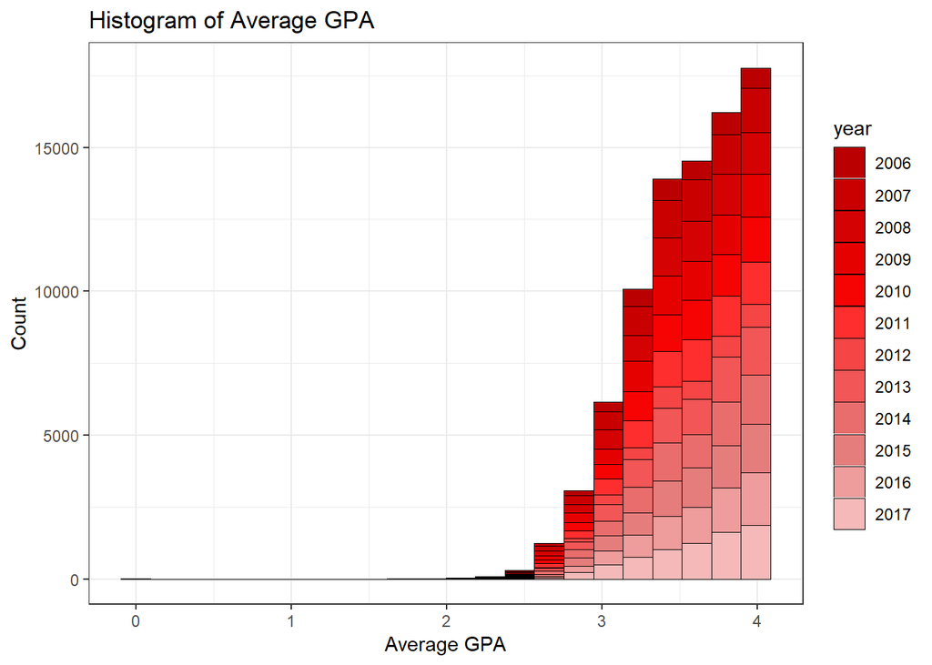

```r
g1 <- ggplot(madison_grades, aes(average_gpa)) + theme_bw()
g1_colors <- scale_fill_manual(values =c('#BA0000','#C90000','#D40202','#E60101','#F60404','#FF2E2E','#F54545','#F35656','#E96D6D','#E67D7D','#EE9C9C','#F5B9B9'))
g1_labs <- labs(title='Histogram of Average GPA', x = 'Average GPA', y = 'Count')
g1 + g1_colors + g1_labs + geom_histogram(aes(fill=year), binwidth = .19, col = 'black', size = .1)
```

##### (b) Are there any courses, sections, or subjects, that stand out as having the lowest average GPA or the highest average GPA?

In order to find the average GPA for every subject, I used “tapply()” to store these values in a new data frame.

```r
subject_gpa_summary <- tapply(madison_grades$average_gpa[!is.na(madison_grades$average_gpa)], madison_grades$subject[!is.na(madison_grades$average_gpa)], mean)
subject_gpa_summary <- na.omit(data.frame(subject = names(subject_gpa_summary), average_gpa = subject_gpa_summary))
```

I also sorted the data from lowest average_gpa to highest average_gpa and renamed the rows to clean it up a little bit.

```r
subject_gpa_summary <- subject_gpa_summary[order(subject_gpa_summary$average_gpa),]
rownames(subject_gpa_summary) <- c(1:190)
```

I then wanted to take a moment to look at the highest and lowest average GPA’s based on subject.

```r
tail(subject_gpa_summary, n = 10)
```

```
##                                    subject average_gpa
## 181                 Biomolecular Chemistry    3.944036
## 182                           Neuroscience    3.950565
## 183                       Physical Therapy    3.965253
## 184                   Neurological Surgery    3.970253
## 185                            Agroecology    3.971799
## 186                Biology Core Curriculum    3.980506
## 187                        Family Medicine    3.981838
## 188 Medical Sciences - Veterinary Medicine    4.000000
## 189                      Molecular Biology    4.000000
## 190      Ophthalmology and Visual Sciences    4.000000
```

```r
head(subject_gpa_summary, n = 10)
```

```
##                                   subject average_gpa
## 1                             Mathematics    3.107717
## 2          Biological Systems Engineering    3.221458
## 3                                     Law    3.228405
## 4            Farm & Industry Short Course    3.241174
## 5                           Legal Studies    3.256005
## 6  Engineering Mechanics and Astronautics    3.264592
## 7                        WILDLIFE ECOLOGY    3.304407
## 8                               Chemistry    3.310079
## 9      Accounting and Information Systems    3.324651
## 10                             Statistics    3.327369
```

One of the variables that might influence how these grades are viewed is the total number of graded students that took each subject. I again used “tapply()” to find these values and then merged this data with the current *subject_gpa_summary* into a new data frame *gpa_analysis*.

```r
total_students <- tapply(madison_grades$total_graded_students, madison_grades$subject, sum)
total_students <- na.omit(data.frame(subject = names(total_students), total_graded_students = total_students))
gpa_analysis <- merge(subject_gpa_summary,total_students)
gpa_analysis <- gpa_analysis[order(gpa_analysis$average_gpa),]
```

Now that I counted the number of students for each subject, I wanted to use a jitter plot to observe the relationship between the total number of graded students and average GPA.

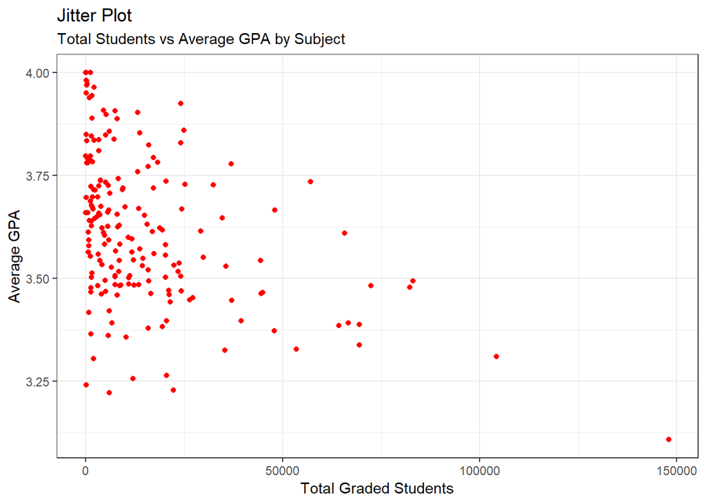

```r
p1 <- ggplot(gpa_analysis, aes(total_graded_students,average_gpa))
p1_labs <- labs(title = "Jitter Plot", subtitle = "Total Students vs Average GPA by Subject", x = 'Total Graded Students', y = 'Average GPA')
p1 + p1_labs + geom_jitter(width =.5, size = 1.5, col = 'red') + theme_bw()
```

One of the reasons I wanted to consider the number of students graded in each subject and compare it to the average GPA is because it would make sense that the less students that are graded, the more volatile the average GPA.

In order to account for this, I considered the subjects where the total number of graded students were above the 25th percentile of the data. To do this, I used the “quantile()” function to find the percentiles of *total_graded_students*.

```r
quantile(gpa_analysis$total_graded_students)
```

```
##     0%    25%    50%    75%   100%
##     14   2134   8006  20045 147994
```

With this information, I subset **gpa_analysis** to remove rows for which *total_graded_students* was below 2134.

```r
upper_75th <- gpa_analysis[which(gpa_analysis$total_graded_students > 2134),]
```

Then, I used this information to visualize the top 10 subjects with the highest average GPA and the top 10 subjects with the lowest average GPA.

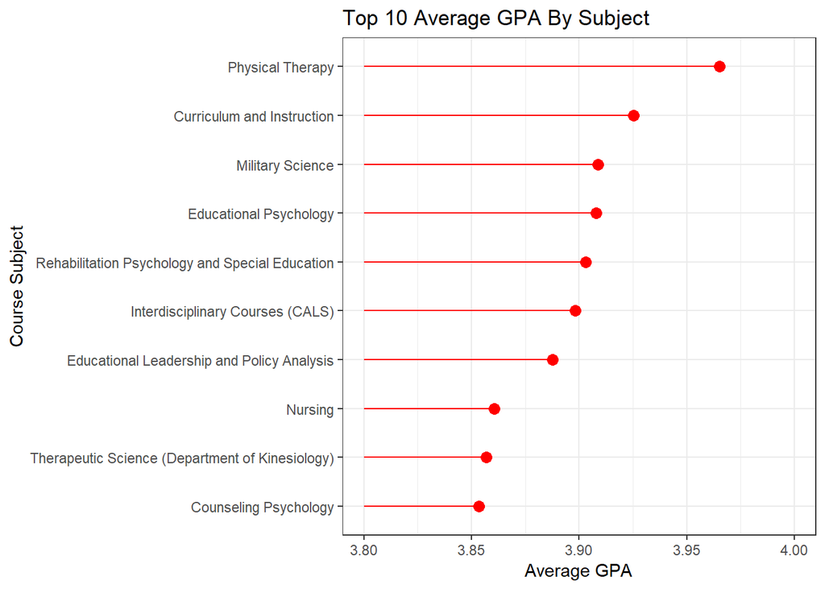

```r
top10 <- tail(upper_75th, n = 10)
top10$subject <- reorder(top10$subject,top10$average_gpa)
p2 <- ggplot(top10, aes(subject,average_gpa)) + theme_bw() + ylim(3.8,4)
p2_labs <- labs(title = 'Top 10 Average GPA By Subject', y = 'Average GPA', x = 'Course Subject')
p2_lollipop <- geom_segment(aes(x = subject , xend = subject, y = 3.8, yend = average_gpa), color = 'red')
p2 + p2_labs + p2_lollipop + geom_point(size = 3, color = 'red') + coord_flip()
```

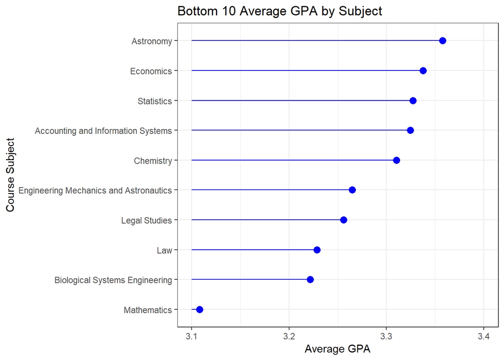

```r
bottom10 <- head(upper_75th, n = 10)
bottom10$subject <- reorder(bottom10$subject,bottom10$average_gpa)
p3 <- ggplot(bottom10, aes(subject,average_gpa)) + theme_bw() + ylim(3.1,3.4)
p3_labs <- labs(title = 'Bottom 10 Average GPA by Subject', y = 'Average GPA', x = 'Course Subject')
p3_lollipop <- geom_segment(aes(x = subject, xend = subject, y = 3.1, yend = average_gpa), color = 'blue')
p3 + p3_labs + p3_lollipop + geom_point(size = 3, color = 'blue') + coord_flip()
```

In order to better understand these subjects, I wanted to take a look at some of the data associated with them.

The first one I wanted to take a look at was the subject “Curriculum and Instruction”. Since I had never heard of this subject before, I decided to go to University of Wisconsin’s website to find out more information and maybe understand a little more background at https://ci.education.wisc.edu/. As a direct quote from the website

*The Department of Curriculum and Instruction is a premier research and teaching unit devoted to understanding the complex world of teaching, learning, curriculum, and policy. World-class research is the foundation of our work preparing both the next generation of educational researchers as well as future teachers.*

What I found really interesting about this program is that it turns out this particular program at University of Wisconsin, Madison is ranked one of the top Curriculum and Instruction programs in the country. It is ranked as the #2 Best Curriculum and Instruction Program in 2019 by US News and World Report here https://www.usnews.com/best-graduate-schools/top-education-schools/curriculum-instruction-rankings and was previously ranked #1 back in 2017 as chronicled in an article from the School of Education here [https://www.education.wisc.edu/soe/news-events/news/2016/03/16/u-s–news-again-ranks-uw-madison-school-of-education-no–1-among-public-institutions](https://www.education.wisc.edu/soe/news-events/news/2016/03/16/u-s--news-again-ranks-uw-madison-school-of-education-no--1-among-public-institutions). Countless of other sources note this as one of the top Education schools in the country, trailing behind Harvard, Stanford, and UCLA. I found this interesting since the data is supporting the fact that people who take the courses for the graduate program tend to do quite well.

With that, I wanted to then take a look at the courses with the lowest average GPA. The most obvious subject with the lowest average GPA was the subject “Mathematics”. This was particularly interesting because it was the subject with the highest number of graded students out of every subject. To better understand why Math had such a low average GPA, I wanted to observe more about the particular courses.

The first thing I did was take out all of the average GPA’s that have “NA” values so that I could use tapply() to compute the average GPA for each course.

```r
madison_analysis <- madison_grades[!is.na(madison_grades$average_gpa),]
```

Now, similar to **subject_gpa_summary**, I found the average GPA of each individual course that is associated with the subject Mathematics.

```r
math_gpa <- tapply(madison_analysis$average_gpa[which(madison_analysis$subject == 'Mathematics')],
                   madison_analysis$course_name[which(madison_analysis$subject == 'Mathematics')], mean)
math_gpa <- na.omit(data.frame(course = names(math_gpa), average_gpa = math_gpa))
math_gpa <- math_gpa[order(math_gpa$average_gpa),]
rownames(math_gpa) <- c(1:dim(math_gpa)[1])
head(math_gpa, n = 10)
```

```
##                                       course average_gpa
## 1                       Intermediate Algebra    2.524482
## 2                                    Algebra    2.601855
## 3  Calculus with Algebra and Trigonometry II    2.634020
## 4                               Trigonometry    2.661637
## 5                   Algebra and Trigonometry    2.731014
## 6   Calculus with Algebra and Trigonometry I    2.735581
## 7              Applied Mathematical Analysis    2.739027
## 8           Calculus and Analytic Geometry 2    2.755741
## 9                  Topics-Finite Mathematics    2.786842
## 10           Fundamental Mathematical Skills    2.791721
```

```r
tail(math_gpa, n = 10)
```

```
##                                     course average_gpa
## 140 Seminar-The Foundations of Mathematics           4
## 141                    Seminar in Analysis           4
## 142               Seminar in Number Theory           4
## 143                    Seminar in Topology           4
## 144                  Smr in Math Education           4
## 145                      Special Functions           4
## 146           Topics in Algebraic Topology           4
## 147              Topics in Applied Algebra           4
## 148                Topics in Combinatorics           4
## 149           Topics in Geometric Topology           4
```

When the data was viewed in this manner, it seems less surprising that Mathematics is the subject with the lowest average GPA. Almost every student is required to take some form of mathematics during their college career and a large set of majors require at least basic algebra or trigonometry. Since almost everyone was required to take these courses, they have a lot of students which also means there are probably some classes that are outliers. In order to see these, I wanted to create a box plot of the top 20 mathematics courses with the lowest average GPA. First I subset the data into a data frame and then I used **math_top20** to create a box plot using ggplot2.

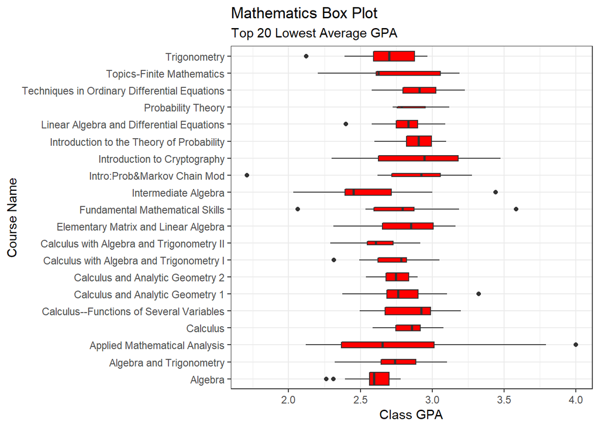

```r
math_top20 <- madison_analysis[madison_analysis$course_name %in% head(math_gpa$course, n = 20),]
p4 <- ggplot(math_top20, aes(course_name, average_gpa)) + theme_bw()
p4_labs <- labs(title = 'Mathematics Box Plot', subtitle = "Top 20 Lowest Average GPA", x = "Course Name",y = 'Class GPA')
p4 + geom_boxplot(varwidth = T, fill = 'red') + p4_labs +  coord_flip()
```

From this visualization, it was clear that the average GPA of these courses ranged anywhere from around 2.5 to slightly more than 3.0. What was most interesting about these visual to me were the outliers. Trigonometry and Algebra were two of classes with the highest concentration of students and both had some very low outliers. Comparatively, Applied Mathematical Analysis and Intermediate Algebra had two of the lowest average GPA’s but had two high outliers.

##### (c) Do the grades given by individual instructors seem to stay the same over time or do they have any type of trend over time? If there is a trend, is it consistent across instructors or does it vary among instructors?

The first thing I did was calculate the average gpa for each instructor by year.

```r
yearly_gpa <- aggregate(madison_analysis$class_gpa, by = list(madison_analysis$instructor, madison_analysis$year), mean)
colnames(yearly_gpa) <- c('instructor','year','year_gpa')
head(yearly_gpa)
```

```
##              instructor year year_gpa
## 1            A-XING ZHU 2006 3.081871
## 2           A IVAN SOLL 2006 2.975000
## 3          AARON BROWER 2006 4.000000
## 4  AARON MARCUS SPOONER 2006 3.328125
## 5 AARON MICHAEL JOSSART 2006 3.704545
## 6   ABBY JOHANNA KINCHY 2006 3.613095
```

Then I counted the number of times a professor’s name showed up. I wanted to analyze professors that had taught every year from 2006 to 2017 so I wanted to analyze professors with a frequency count of 12.

```r
w <- plyr::count(yearly_gpa, vars = c('instructor'))
w <- w[which(w$freq == 12),]
head(w)
```

```
##         instructor freq
## 2       A-XING ZHU   12
## 96  AGNETE SCHMIDT   12
## 108   AKBAR SAYEED   12
## 110  AKI HASHIMOTO   12
## 117 ALAN G SIDELLE   12
## 128 ALAN TALARCZYK   12
```

```r
dim(w)
```

```
## [1] 428   2
```

This left 428 professors. I then merged **yearly_gpa** and **w** together.

```r
yearly_gpa <- merge(yearly_gpa,w)
yearly_gpa <- yearly_gpa[,-4] # remove frequency from data
```

By doing this, now I could calculate the variance of the average gpa by year for each professor.

```r
gpa_var <- aggregate(year_gpa ~ instructor, data = yearly_gpa, var)
colnames(gpa_var)[2] <- 'variance'
summary(gpa_var$variance)
```

```
##      Min.   1st Qu.    Median      Mean   3rd Qu.      Max.
## 7.447e-05 8.808e-03 1.998e-02 3.150e-02 4.051e-02 2.280e-01
```

Overall, the variance of these professors was quite small. What this tells me is that more than likely, there is very little change in average GPA over the course of every year. This would probably vary slightly, and I can imagine that the variance is heavily dependent on the courses being taught, but overall their trend is pretty flat and there isn’t a whole lot of fluctuation.

One professor that did stand out to me was “Fabian Waleffe”. This was one of the professors that showed up in the average GPA analysis as one of the professors that taught the math classes with the lowest average GPA. Now, he also showed up in the top 10 instructors with the highest average grade variance so I took a closer look at this professor and to see which classes he taught.

```r
gpa_var <- gpa_var[order(gpa_var$variance),]
tail(gpa_var, n = 10)
```

```
##               instructor  variance
## 111       FABIAN WALEFFE 0.1347093
## 372        SHUCHI CHAWLA 0.1418958
## 63          CLARK LANDIS 0.1450953
## 252    MARSHALL ONELLION 0.1511375
## 12           AMIR ASSADI 0.1580903
## 294    NICHOLAS L ABBOTT 0.1600327
## 168           JIN-YI CAI 0.1771725
## 389         TEHSHIK YOON 0.1960181
## 284      MIKHAIL FELDMAN 0.1961100
## 386 SUNDARAM GUNASEKARAN 0.2280246
```

First I subset **madison_analysis** into a new variable, **fabian**. Then I aggregated the data to get the average gpa based on the *course_name* and changed the column names so I could merge it back together with **fabian**. Finally I displayed a bar graph by year that showed the change in average GPA based on courses for each year.

```r
fabian <- madison_analysis[which(madison_analysis$instructor == 'FABIAN WALEFFE'), c(3:7,37)]
fabian_summary <- aggregate(class_gpa ~ course_name + year, data = fabian, mean)
head(fabian_summary)
```

```
##                        course_name year class_gpa
## 1           Adv Meth of Appld Math 2006  3.846154
## 2    Applied Mathematical Analysis 2006  2.351351
## 3    Applied Mathematical Analysis 2007  2.273148
## 4    Applied Mathematical Analysis 2008  2.339744
## 5    Applied Mathematical Analysis 2009  2.451531
## 6 Methods of Applied Mathematics-2 2009  3.562500
```

```r
colnames(fabian_summary)[3] <- 'avg_gpa'
fabian <- merge(fabian,fabian_summary)
```

Once that was finished I was able to visualize the data.

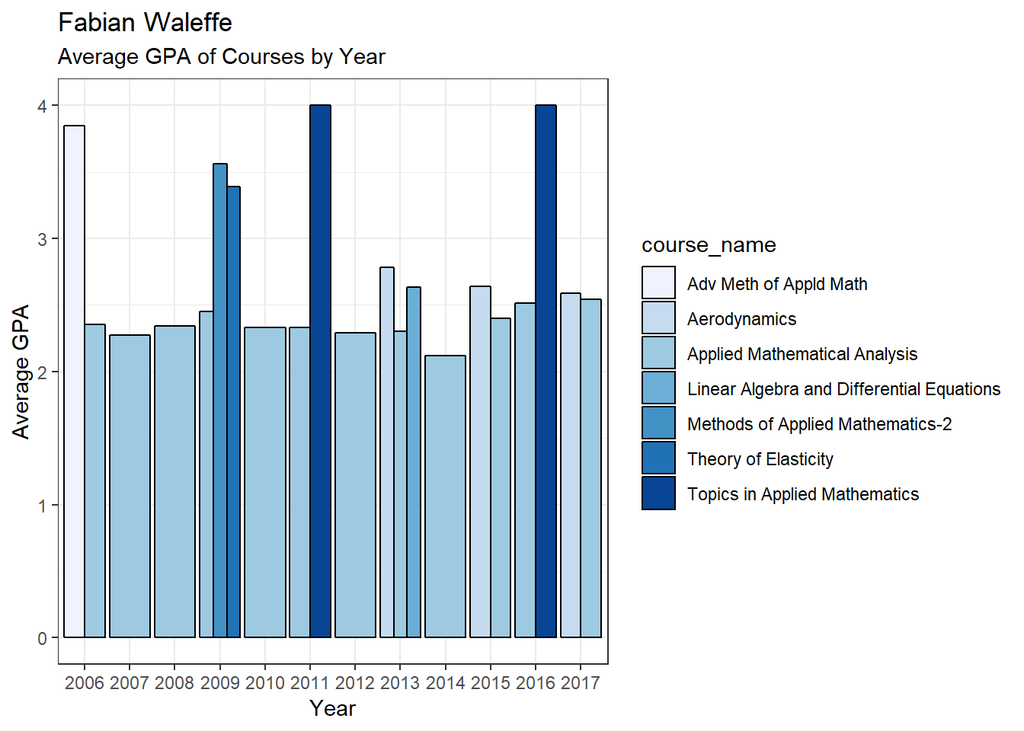

```r
p5 <- ggplot(fabian, aes(x = year, y = avg_gpa, fill = course_name)) + theme_bw()
p5_labs <- labs(title = 'Fabian Waleffe', subtitle = 'Average GPA of Courses by Year',x = 'Year', y = 'Average GPA')
p5_color <- scale_fill_brewer(palette = 'Blues')
p5 + p5_labs + p5_color + geom_bar(stat = 'identity', position = 'dodge', col = 'black')
```

What this graph told me is that the course “Applied Mathematical Analysis” was not only offered and taught by him every single year, but it also was consistently the course with the lowest average GPA regardless of the year. Having taken an applied mathematics course, this makes sense. The Applied Mathematics for Science and Engineering course at Sacramento State was one of the hardest courses I have ever taken. The math is complicated, and it is not only highly computational but it is also highly theoretical. The combination of the two makes for a very difficult course. The fact that Fabian Waleffe has taught this course for 12 years straight also suggests that his area of research is in applied mathematics which was easily confirmed with one quick visit to his school website page https://www.math.wisc.edu/~waleffe/.

##### (d) Which 5 subject areas had the most professors in 2017? Pick a subject area with many professors. Scrape the data on the professor’s ratings from rate my professor and determine if these ratings have any correlation with the overal average GPA assigned by a professor.

To answer this question, I first subset the data to include only data from 2017.

```r
uw_2017 <- madison_analysis[which(madison_analysis$year == '2017'),]
```

Next I counted the number of classes of each subject each instructor taught.

```r
a <- plyr::count(uw_2017, vars = c('subject','instructor'))
head(a, n = 3)
```

```
##                              subject            instructor freq
## 1 Accounting and Information Systems        ALAN TALARCZYK    6
## 2 Accounting and Information Systems ANDREW JOSEPH PASCALY    1
## 3 Accounting and Information Systems           ANN O'BRIEN    6
```

Since this counted the number of classes taught by individual instructors for each subject, I aggregated the sum of the number of classes taught by unique professors for each subject.

```r
b <- aggregate(freq ~ subject, a, sum)
b <- b[order(b$freq),]
tail(b)
```

```
##                                 subject freq
## 52  Electrical and Computer Engineering  156
## 34                   Communication Arts  187
## 170    Spanish (Spanish and Portuguese)  195
## 111                         Mathematics  218
## 13                       Art Department  221
## 57                              English  257
```

Since I am a math major, it was obviously most intriguing to me to scrape the data of the mathematics professors. As someone who has spent a lot of time on rate my professor and have read through reviews of all the professors I have taken, I am most interested to see the correlation of the reviews and average gpa.

To do this, I first subset **uw_2017** to only show data for the subject Mathematics.

```r
uw_math <- uw_2017[which(uw_2017$subject == 'Mathematics'),]
```

Instead of counting the number of classes each professor taught, I counted the number of graded students each professor had. This increased the likelihood of finding a large number of reviews and the gpa would most likely be a more accurate reflection of how well people did in the course because there were more data points.

```r
students <- aggregate(total_graded_students ~ instructor, uw_math, sum)
students <- students[order(students$total_graded_students),]
tail(students, n = 5)
```

```
##           instructor total_graded_students
## 5  ALEXANDER HANHART                   501
## 46     JOSEPH MILLER                   511
## 51   LAURENTIU MAXIM                   523
## 92      TONGHAI YANG                   641
## 20      DANIEL ERMAN                   715
```

Using this, I took these five professors and scraped the data on rate my professor of their ratings and level of difficulty.

```r
prof1 <- html_text(html_nodes(read_html('https://www.ratemyprofessors.com/ShowRatings.jsp?tid=1852275'),'.breakdown-header .grade'))
prof1 <- trimws(prof1, which = c('both'))
prof1 <- as.numeric(unlist(strsplit(prof1,split = '%')))
#Daniel Erman

prof2 <- html_text(html_nodes(read_html('https://www.ratemyprofessors.com/ShowRatings.jsp?tid=2043547'),'.breakdown-header .grade'))
prof2 <- trimws(prof2, which = c('both'))
prof2 <- as.numeric(unlist(strsplit(prof2,split = '%')))
#Tonghai Yang

prof3 <- html_text(html_nodes(read_html('https://www.ratemyprofessors.com/ShowRatings.jsp?tid=1408142'),'.breakdown-header .grade'))
prof3 <- trimws(prof3, which = c('both'))
prof3 <- as.numeric(unlist(strsplit(prof3,split = '%')))
#Laurentiu Maxim

prof4 <- html_text(html_nodes(read_html('https://www.ratemyprofessors.com/ShowRatings.jsp?tid=1356509'),'.breakdown-header .grade'))
prof4 <- trimws(prof4, which = c('both'))
prof4 <- as.numeric(unlist(strsplit(prof4,split = '%')))
#Joe Miller

prof5 <- html_text(html_nodes(read_html('https://www.ratemyprofessors.com/ShowRatings.jsp?tid=2094033'),'.breakdown-header .grade'))
prof5 <- trimws(prof5, which = c('both'))
prof5 <- as.numeric(unlist(strsplit(prof5,split = '%')))
#Alexander Hanhart
```

I then stores these in their respective variables and converted them into a data frame.

```r
ratings <- c(prof1[1], prof2[1], prof3[1], prof4[1], prof5[1])
take_again <- c(prof1[2], prof2[2],prof3[2], prof4[2], prof5[2])
difficulty <- c(prof1[3], prof2[3],prof3[3], prof4[3], prof5[3])
instructor <- c('DANIEL ERMAN', 'TONGHAI YANG', 'LAURENTIU MAXIM', 'JOSEPH MILLER', 'ALEXANDER HANHART')
prof_ratings <- data.frame(ratings, take_again, difficulty, instructor)
prof_ratings
```

```
##   ratings take_again difficulty        instructor
## 1     4.8        100        3.1      DANIEL ERMAN
## 2     3.1         83        2.9      TONGHAI YANG
## 3     3.8         57        3.2   LAURENTIU MAXIM
## 4     2.7         46        3.3     JOSEPH MILLER
## 5     3.6         68        3.7 ALEXANDER HANHART
```

After that, I subset the data only for the math professors I scraped data for. I used the data from **madison_analysis** since the data on rate my professors is aggregated data and therefore it took into account information across all years. I also removed any information from **madison_analysis** that was unecessary.

```r
prof_analysis <- madison_analysis[madison_analysis$instructor %in% tail(students$instructor, n = 5),-c(1,2,8:24,26,29:36,38:40)]
```

Earlier, I calculated *total_passing* and *total_failing* and now I used those to calculate the proportion of students who are failing and passing. These were complimets of one another so P(passing) = 1 - P(failing).

```r
prof_analysis$p_failing <- prof_analysis$total_failing / prof_analysis$total_pass_fail_students
prof_analysis$p_passing <- 1 - prof_analysis$p_failing
```

Then I calculated the average gpa for each professor and merged it back into **prof_analysis**.

```r
prof_gpa <- aggregate(class_gpa ~ instructor, prof_analysis, mean)
colnames(prof_gpa)[2] <- "prof_avg"
prof_gpa
```

```
##          instructor prof_avg
## 1 ALEXANDER HANHART 2.745958
## 2      DANIEL ERMAN 3.120251
## 3     JOSEPH MILLER 3.141684
## 4   LAURENTIU MAXIM 3.363744
## 5      TONGHAI YANG 3.292799
```

```r
prof_analysis <- merge(prof_analysis,prof_gpa)
```

Finally I took **prof_ratings** and merged it together with **prof_analysis**. I then factored the difficulty to set it up for the visualization.

```r
prof_analysis <- merge(prof_analysis,prof_ratings)
prof_analysis$difficulty <- factor(prof_analysis$difficulty)
```

Now that I had all the data that I needed, I created a scatter plot to analyze the data.

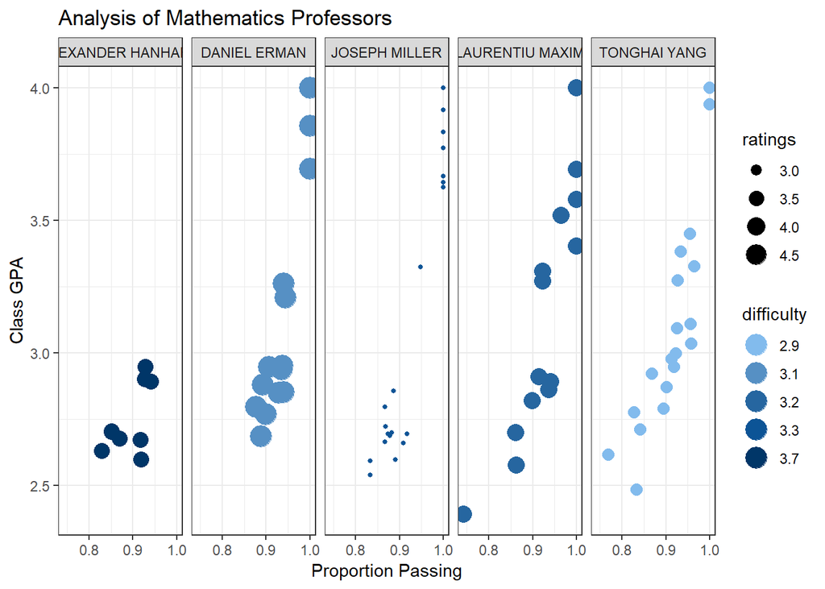

```r
p6 <- ggplot(prof_analysis, aes(x = p_passing, y = class_gpa, size = ratings, col = difficulty)) + theme_bw()
p6_labs <- labs(title = 'Analysis of Mathematics Professors', x = 'Proportion Passing', y = 'Class GPA')
p6_color <- scale_color_manual(values = c('#82bbed','#5690c4','#2666a0','#0c5496','#003668'))
p6_guides <- guides(colour = guide_legend(override.aes = list(size = 6)))
p6 + p6_labs + facet_grid(.~instructor) + geom_point() + p6_guides + p6_color
```

I separated the data for this visual by each of the professors to better analyze the results. On the x-axis is the proportion of students who passed the class and on the y-axis is the class gpa. Also, the larger the size of the dot the higher the rating the professor received on Rate My Professor. Then, the difficulty rating is color coded by the legend on the right side of the graph. The more difficult the class was rated, the darker the color of the dot.

One of the most obvious correlations I saw from this graph was from the professor Daniel Erman. He was given somewhat of a lower difficulty rating but was given the highest overall positive rating of all the professors. Also, he had quite a few classes that had a higher average gpa and a high proportion of students passing.

```r
prof_analysis[which(prof_analysis$instructor == 'DANIEL ERMAN'),c(1,3,9)]
```

```
##      instructor                           course_name class_gpa
## 10 DANIEL ERMAN      Calculus and Analytic Geometry 2  2.768145
## 11 DANIEL ERMAN      Calculus and Analytic Geometry 2  2.951673
## 12 DANIEL ERMAN      Calculus and Analytic Geometry 2  2.946667
## 13 DANIEL ERMAN              Elementary Number Theory  3.208333
## 14 DANIEL ERMAN                 Topics in Ring Theory  3.857143
## 15 DANIEL ERMAN      Calculus and Analytic Geometry 2  2.850943
## 16 DANIEL ERMAN      Calculus and Analytic Geometry 2  2.938034
## 17 DANIEL ERMAN      Calculus and Analytic Geometry 2  2.848739
## 18 DANIEL ERMAN                        Modern Algebra  2.878378
## 19 DANIEL ERMAN                        Modern Algebra  3.260417
## 20 DANIEL ERMAN      Calculus and Analytic Geometry 2  2.796053
## 21 DANIEL ERMAN      Calculus and Analytic Geometry 2  2.684549
## 22 DANIEL ERMAN Advanced Topics in Algebraic Geometry  4.000000
## 23 DANIEL ERMAN                      Abstract Algebra  3.694444
```

It looks like one of the classes he taught, Calculus and Analytic Geometry 2, had a consistent average GPA below a 3.0 while the other courses were not quite as low. With a quick google search it turns out his emphasis is algebraic and commutative algebra. It could have been that those classes just had less difficult subject matter or it could be that he was more enthusiastic about teaching those classes.

## Conclusion

This data was extremely fun to work with. Not only was the task of compiling all of the data together and cleaning it in an efficient manner fun, but the results that came out of this data were interesting. Even though I have finished this project, I would like to explore the data a little bit more to find results for some of my unanswered questions. One of the biggest tasks I did not get around to doing was using machine learning to predict GPA. Earlier, when I created a column for claffifying GPA’s as below or above average, my goal was to collect enough data and create a clean data frame that could be used to find the predictive factors of a class having above or below an average GPA. Also, I would have liked to have further investigated other subjects other than Mathematics. One of the findings I discovered early on in the data was that most classes related to the medical field had consistently high average GPA scores. In the future, it would be fun to collect all of these courses and analyze the information associated with them such as number of students, year, semester, professor, and so on. All in all, I am thrilled to have completed my first full data analysis project.